# Johns Hopkins Data Science Casptone Project - Milestone Report

Gregorio Ambrosio Cestero

June 4, 2016

updated: 2016-06-13 21:44:13

## Introduction

Natural language processing (NLP) is a field of computer science, artificial intelligence, and computational linguistics concerned with the interactions between computers and human (natural) languages. As such, NLP is related to the area of human–computer interaction. Many challenges in NLP involve: natural language understanding, enabling computers to derive meaning from human or natural language input; and others involve natural language generation.

Around the world, people are spending an increasing amount of time on their mobile devices for email, social networking, banking and a whole range of other activities. But typing on mobile devices can be a serious pain. SwiftKey company builds a smart keyboard that makes it easier for people to type on their mobile devices. One cornerstone of their smart keyboard is predictive text models.

This report is part of the Coursera John Hopkins Data Science Capstone Project. The course starts with the basics, analyzing a large corpus of text documents to discover the structure in the data and how words are put together. It covers cleaning and analyzing text data, then building and sampling from a predictive text model. Finally, a predictive text product will be built.

This milestone report provides a first stage in the project providing data acquisition and cleaning, and exploratory analysis of the course data set.

## Executive summary

Exploratory Data Analysis techniques are typically applied before formal modeling commences and can help inform the development of more complex statistical models. Exploratory techniques are also important for eliminating or sharpening potential hypotheses about the world that can be addressed by the data. To get started Coursera Swiftkey Dataset is downloaded and then some statistics are collected. Since the size of the data set is very big it is randomly sampled to a reduced data set to address the analysis. This sample data set is preprocessed and tokenized for extracting contiguous sequence of items. Concretely unigrams, bigrams and trigrams are extracted. Finally, word clouds for n-grams are showed.

## Loading data set

The data set comes from [HC Corpora](http://www.corpora.heliohost.org) and is composed of four language corpus: en_US, de_DE, ru_RU and fi_FI. See the [readme file](http://www.corpora.heliohost.org/aboutcorpus.html) for details on the corpora available. The files have been language filtered but may still contain some foreign text. In this report the english one in chosen to be analyzed.

```r
### Loading needed packages
# p_load = install.packages + library

if (!require("pacman")) install.packages("pacman", dependencies=TRUE)
```

```r
pacman::p_load(stringi, tm, RWeka, ggplot2, magrittr, SnowballC, wordcloud, Rgraphviz)
```

```r
### Loading Dataset

destFile <- "Coursera-SwiftKey.zip"
fileURL <- paste("http://d396qusza40orc.cloudfront.net/dsscapstone/dataset/", destFile, sep="")
if (!file.exists(destFile)) download.file(fileURL ,destFile)

# Unzziping and setting directories

# Checking if it was previously unzipped
corpora.path       <- "final/en_US"
if (!(file.exists(corpora.path))) unzip(destFile)
corpora.files      <- file.path(corpora.path, list.files(corpora.path))

# Creating sample directory
corpora.samplePath <- "sample"
if (!file.exists(corpora.samplePath)) dir.create(corpora.samplePath)
```

Files sizes are extracted in megabytes

```r
### File size
list.files(corpora.path)
```

```
## [1] "en_US.blogs.txt"   "en_US.news.txt"    "en_US.twitter.txt"
```

```r
file.info(corpora.files)$size / 1024^2
```

```
## [1] 200.4242 196.2775 159.3641
```

Now files are read. As the corpus is composed of three files, a list is used to store them

```r
### Reading data
corpora.data <- vector("list",3)
names(corpora.data) <- basename(corpora.files)

con <- file(corpora.files[1], open="rb")
corpora.data[[1]] <- readLines(con, encoding="UTF-8", skipNul = TRUE)
close(con)

con <- file(corpora.files[2], open="rb")
corpora.data[[2]] <- readLines(con, encoding="UTF-8", skipNul = TRUE)
close(con)

con <- file(corpora.files[3], open="rb")
corpora.data[[3]] <- readLines(con, encoding="UTF-8", skipNul = TRUE)
close(con)

rm(con)
```

## Getting some statistics

To have an idea of how the data set looks like, some statistics are extracted. Pure R can be used for that but, in this case, stringi package is used for simplicity and not reinvent the wheel.

```r
# Number of lines
# Number of non-empty lines
# Number of characters
# Number of non-white characters
# Number of words
corpora.stats <- data.frame(t(rbind(sapply(corpora.data,stri_stats_general),
                                    sapply(corpora.data,stri_stats_latex)[4,]
                                    )
                              )
                            )
colnames(corpora.stats)[5] <- "Words"
print(corpora.stats)
```

```
##                     Lines LinesNEmpty     Chars CharsNWhite    Words
## en_US.blogs.txt    899288      899288 206824382   170389539 37570839
## en_US.news.txt    1010242     1010242 203223154   169860866 34494539
## en_US.twitter.txt 2360148     2360148 162096241   134082806 30451170
```

## Sampling data

This dataset is fairly large. A smaller subset of the data is used by reading in a random subset of the original data and writing it out to a separate file.

```r
### Sampling data
set.seed(1000)

corpora.sample <- vector("list",3)
names(corpora.sample) <- basename(corpora.files)

corpora.sample[[1]] <- corpora.data[[1]][sample(1:length(corpora.data[[1]]),10000)]
corpora.sample[[2]] <- corpora.data[[2]][sample(1:length(corpora.data[[2]]),10000)]
corpora.sample[[3]] <- corpora.data[[3]][sample(1:length(corpora.data[[3]]),10000)]

writeLines(unlist(corpora.sample,recursive=FALSE,use.names=FALSE), file.path(corpora.samplePath,"sampleCorpus.txt"))
```

## Text mining

Analyzing the text data refers to the process of deriving high-quality information from text. This task is referred as text mining. The best way to do text mining in r is using tm package that provides a text mining framework. The main structure for managing documents in tm is a so-called Corpus, representing a collection of text documents. Once loaded, a preprocessing is done removing punctuation, numbers, stopwords, urls, non-needed characters, common word endings in english and unnecesary whitespaces

```r
# Loading sample corpora
corpora.tmCorpus <- Corpus(DirSource(file.path(".", corpora.samplePath)))


# Removing punctuation
corpora.tmCorpus <- tm_map(corpora.tmCorpus, removePunctuation)

# Removing numbers
corpora.tmCorpus <- tm_map(corpora.tmCorpus, removeNumbers)

# Converting to lowercase
corpora.tmCorpus <- tm_map(corpora.tmCorpus, content_transformer(tolower))

# Removing english stop words
corpora.tmCorpus <- tm_map(corpora.tmCorpus, removeWords, stopwords("english"))

# Setting content_transformer to change a pattern to space character
f <- content_transformer(function(x, pattern) gsub(pattern, " ", x))

# Removing URL
corpora.tmCorpus <- tm_map(corpora.tmCorpus, f, "http[[:alnum:]]*")

# Removing some non-needed characters
corpora.tmCorpus <- tm_map(corpora.tmCorpus, f, "/|@|\\|")

# Removing common word endings (e.g., “ing”, “es”, “s”), i.e. stemming words
corpora.tmCorpus <- tm_map(corpora.tmCorpus, stemDocument)

# Stripping unnecesary whitespace
corpora.tmCorpus  <- tm_map(corpora.tmCorpus, stripWhitespace)

# Telling R to treat your preprocessed documents as text documents
corpora.tmCorpus <- tm_map(corpora.tmCorpus, PlainTextDocument)
```

## Tokenization

Now is time to exploratory analysis through the understanding of the distribution of words and relationship between the words in the corpora. Sample data set is tokenized for extracting contiguous sequence of items. Concretely unigrams, bigrams and trigrams are extracted and their frequencies are obtained and plotted.

```r
unigram.tokenizer <- function(x) NGramTokenizer(x, Weka_control(min = 1, max = 1))
bigram.tokenizer  <- function(x) NGramTokenizer(x, Weka_control(min = 2, max = 2))
trigram.tokenizer <- function(x) NGramTokenizer(x, Weka_control(min = 3, max = 3))

unigrams <- DocumentTermMatrix(corpora.tmCorpus, control = list(tokenize = unigram.tokenizer))
bigrams  <- DocumentTermMatrix(corpora.tmCorpus, control = list(tokenize = bigram.tokenizer))
trigrams <- DocumentTermMatrix(corpora.tmCorpus, control = list(tokenize = trigram.tokenizer))

unigrams.frequency <- sort(colSums(as.matrix(unigrams)),decreasing = TRUE)[1:30]
bigrams.frequency  <- sort(colSums(as.matrix(bigrams)),decreasing = TRUE)[1:30]
trigrams.frequency <- sort(colSums(as.matrix(trigrams)),decreasing = TRUE)[1:30]

unigrams.frequency.df <- data.frame(word = names(unigrams.frequency), frequency = unigrams.frequency)
bigrams.frequency.df  <- data.frame(word = names(bigrams.frequency), frequency = bigrams.frequency)
trigrams.frequency.df <- data.frame(word = names(trigrams.frequency), frequency = trigrams.frequency)
```

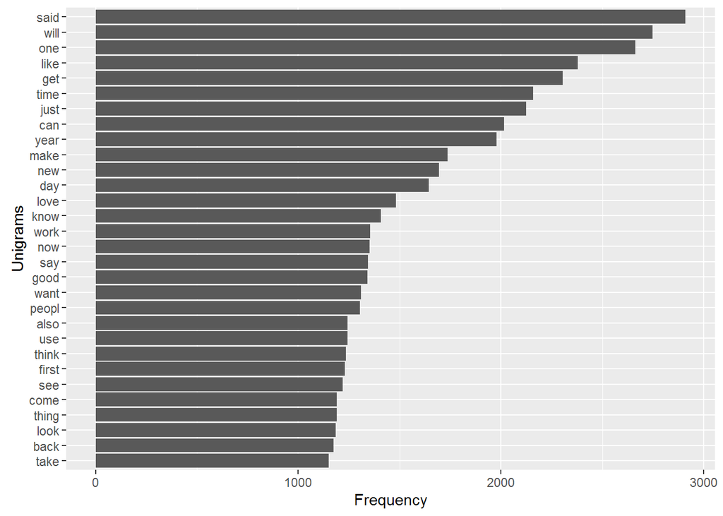

```r
ggplot(unigrams.frequency.df, aes(reorder(word,frequency), frequency)) +
        geom_bar(stat = "identity") +
        xlab("Unigrams") +
        ylab("Frequency") +
        coord_flip()
```

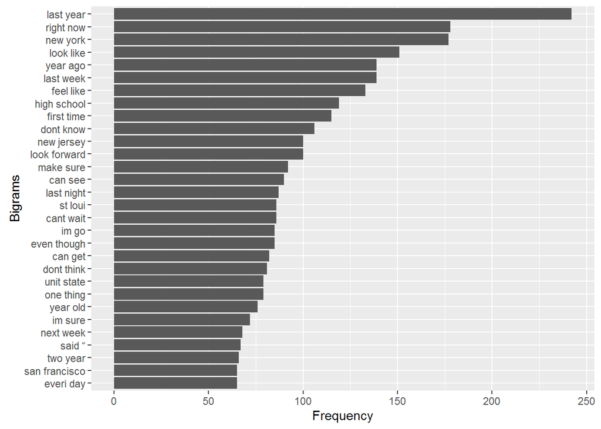

```r
ggplot(bigrams.frequency.df, aes(reorder(word,frequency), frequency)) +
        geom_bar(stat = "identity") +
        xlab("Bigrams") +
        ylab("Frequency") +
        coord_flip()
```

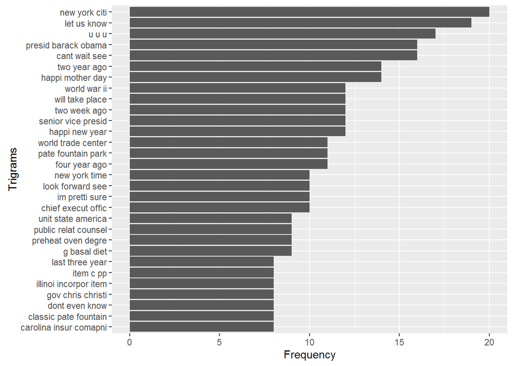

```r
ggplot(trigrams.frequency.df, aes(reorder(word,frequency), frequency)) +
        geom_bar(stat = "identity") +
        xlab("Trigrams") +
        ylab("Frequency") +
        coord_flip()
```

## Word cloud

A more human way of frequencies observation is through word clouds. The wordcloud package is user to plot n-grams in a cloudy way

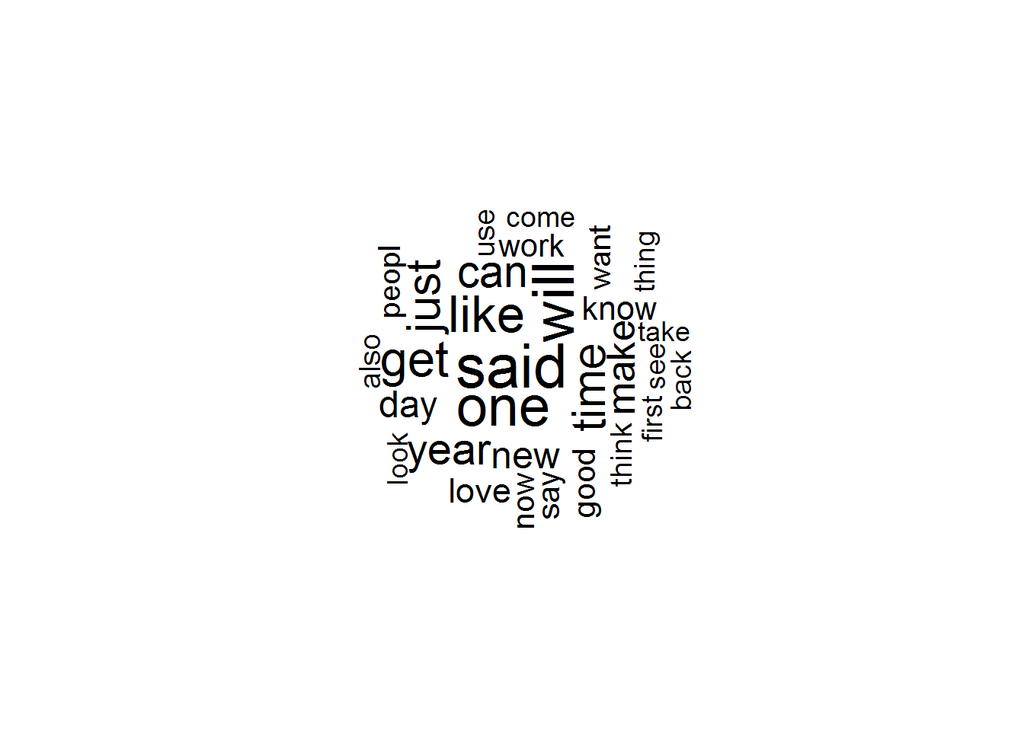

```r
wordcloud(words = names(unigrams.frequency), freq = unigrams.frequency, min.freq = 500,
          scale=c(2.5, .25),
          rot.per=0.50,
          random.order = FALSE)
```

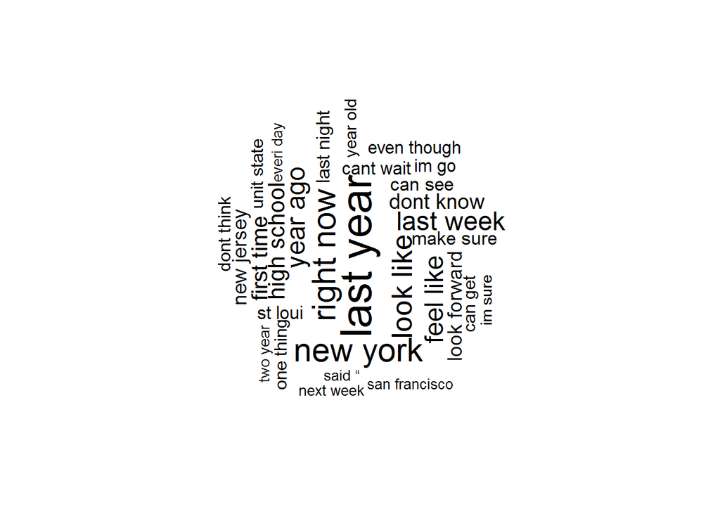

```r
wordcloud(words = names(bigrams.frequency), freq = bigrams.frequency, min.freq = 50,
          scale=c(2.5, .25),
          rot.per=0.50,
          random.order = FALSE)
```

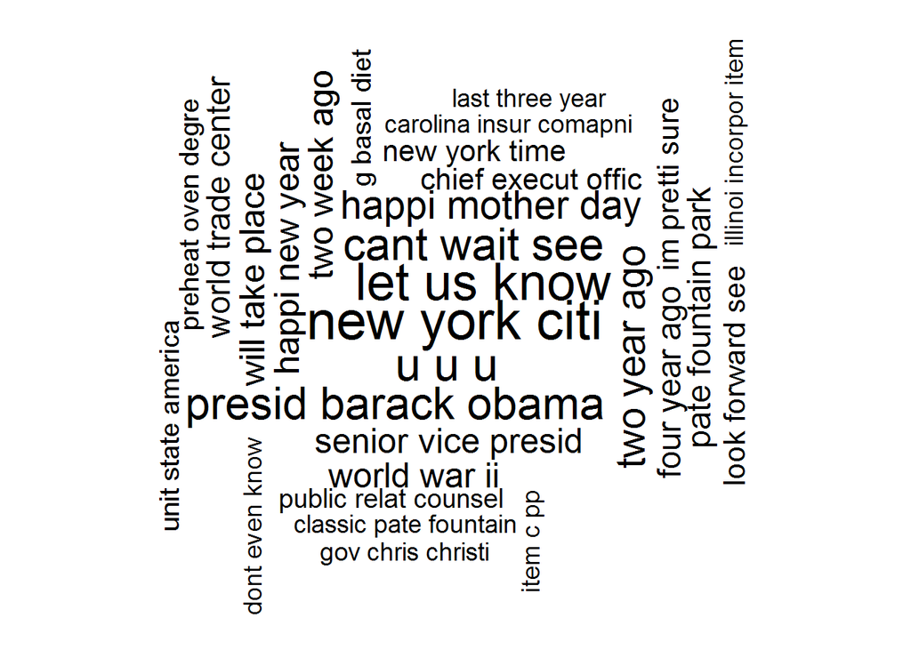

```r
wordcloud(words = names(trigrams.frequency), freq = trigrams.frequency, min.freq = 5,
          scale=c(2.5, .25),
          rot.per=0.50,
          random.order = FALSE)
```

## Next step

To continue the project n-grams will be used to probabilities calculation. Next steps include a n-gram probabilistic based model to next word prediction based on the previous 1, 2 or 3 words. Finally the predcition model will be used trough a shiny app as the goal of the project is defined.